# Stepwise Salary Visualizations

[figure not shown]

[figure not shown]

[figure not shown]

[figure not shown]

[figure not shown]

[figure not shown]

# Model Summary

### Model at a Glance

Observations

233,119

Selected Model

Bidirectional BIC

R-squared

0.562

Model explains 56% of salary variance

BIC

2,016,280

AIC

2,016,155

Predictors (8)

LOSLVL SUPERVIS DATECODE EDLVL AGY LOS AGELVL LOC

Selection method

Direction: **both** Penalty: **k = log(n)** Response: **SALARY / 1000**

### Model Comparison

| Model | Variables | BIC | AIC | R2 |
| --- | --- | --- | --- | --- |
| Forward BIC | 8 | 2,016,280 | 2,016,156 | 0.5625 |
| Bidirectional BIC | 8 | 2,016,280 | 2,016,156 | 0.5625 |
| Simple (LOS+AGE+ED) | 3 | 2,109,971 | 2,109,920 | 0.3458 |

### About This Model

What was done

Three linear regression models were estimated on federal employment salary data. Variable selection used stepwise regression penalised by BIC (`k = log(n)`), which applies a stricter parsimony penalty than AIC, especially at large sample sizes. The bidirectional search both adds and removes variables at each step.

Why BIC over AIC

With over 230,000 observations, AIC tends to retain more variables than necessary. BIC scaling by `log(n)` makes each additional predictor substantially more costly, producing a leaner model less likely to overfit noise in the training data.

Interpreting R²

The selected model explains approximately **56%** of variance in salary. The remaining 44% reflects individual negotiation, within-grade pay steps, performance bonuses, and other factors not present in the dataset.

# Residual Analysis

**Residual Analysis** — Residuals (Actual minus Predicted) reveal where the model succeeds and where it struggles. Ideally residuals are centred at zero with symmetric spread and no systematic patterns across agencies or salary levels.

### Residual Distribution

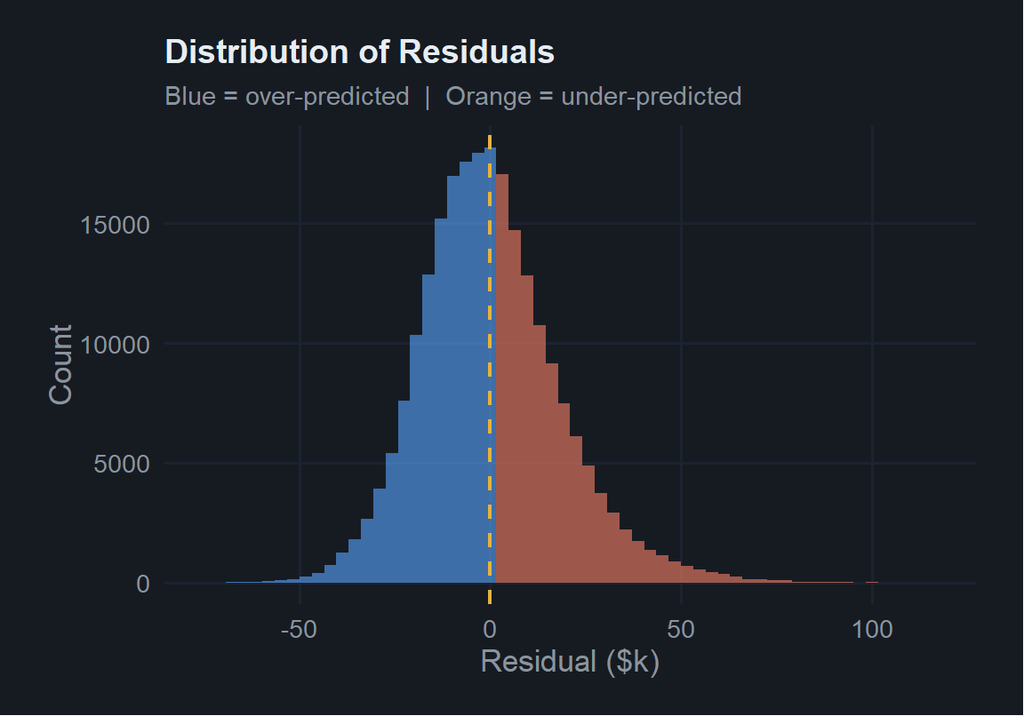

### Predicted vs. Actual

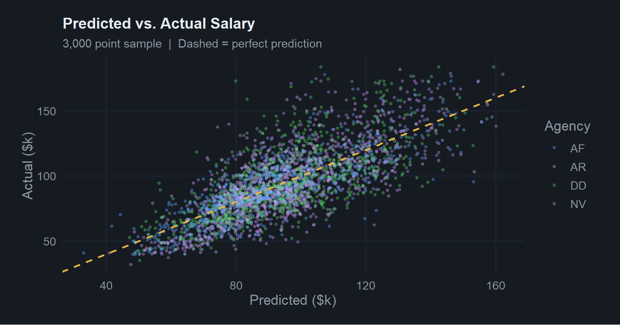

### Residual Distribution — Interpretation

📊

Residuals are roughly centred at zero as expected from OLS. The mild **right skew** is typical for salary data — a small number of very high earners are harder to predict, pulling the distribution rightward. A log transformation of SALARY may reduce this skew in future iterations.

### Predicted vs. Actual — Interpretation

🎯

Points cluster along the 45° line confirming the model captures the central salary trend. The **spread widens at higher salaries** — a classic sign of heteroscedasticity. Senior and specialised roles have more individual variance not explained by the administrative predictors.

### Residuals by Agency

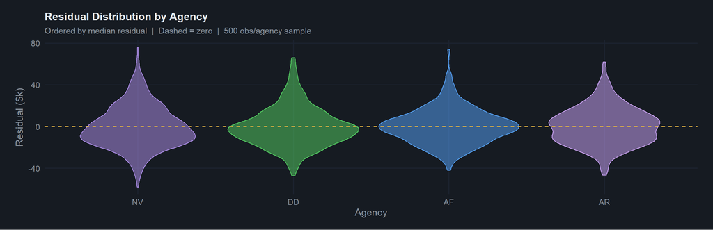

### Residuals by Agency — Interpretation

🏛️

Agencies whose violins sit **above zero** are systematically under-predicted. Those **below zero** are over-predicted. Wide violins indicate high within-agency variance in prediction error, which may reflect heterogeneous job types or pay scales not fully captured by the current predictors.

# Salary Patterns

**Salary Patterns** — Exploring how salary varies with length of service, agency, and education level, and how well the model captures those patterns.

### Salary vs. Length of Service

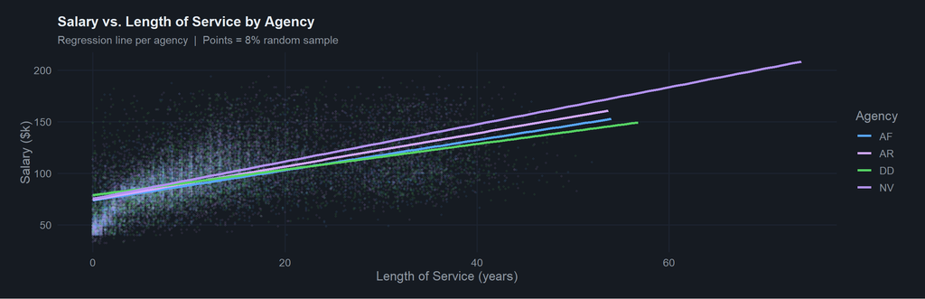

### Length of Service — Interpretation

📈

Each line shows the agency-specific salary growth rate with seniority. **Steeper slopes** indicate a stronger seniority pay premium within that agency. The diverging slopes across agencies supports including both `LOS` and `AGY` as separate predictors. An interaction term `LOS:AGY` would allow the model to capture these differing slopes directly.

### Predicted vs. Actual by Agency

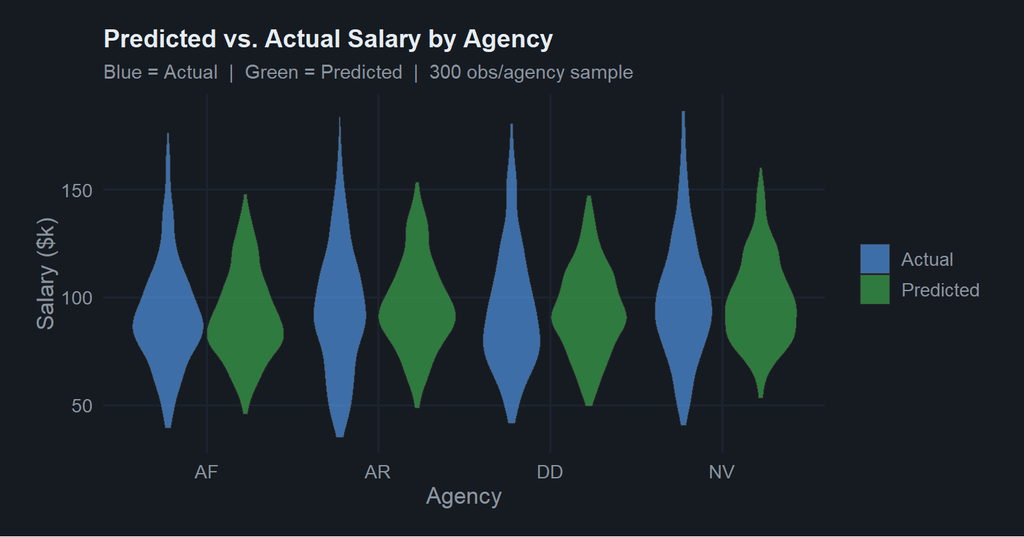

### Salary by Education Level

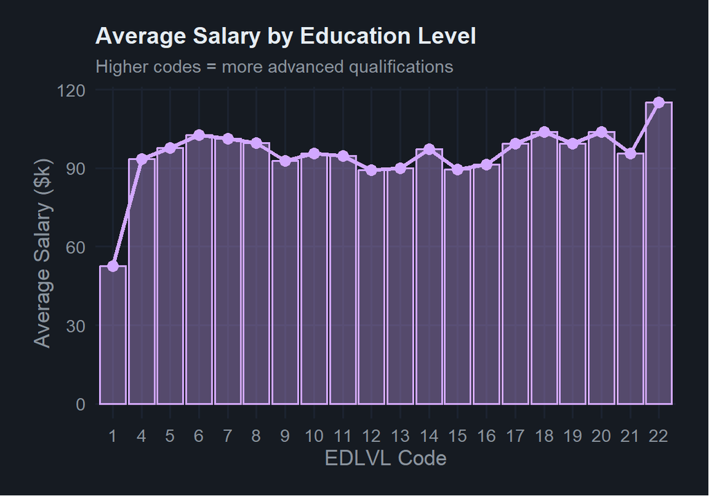

### Predicted vs. Actual — Interpretation

🎻

Paired violins compare actual (blue) and predicted (green) salary distributions per agency. A **narrower predicted violin** indicates the model compresses extreme values — capturing the centre but missing the tails, a known limitation of OLS minimising squared error.

🎓